# valueBoxes and Sparklines

shiny

highcharts

highcharter

htmlwidgets

The value boxes are a good way to get to the point quickly in a dashboard showing the relevant value with a big font and eye-catching color. But sometimes it would be better show that relevant number with a related text, sparkline or information to give context of that value, or just to compare it with the previoues ones. In this post we’ll show how to add sparklines to valueBox in shinydashboard and other related packages.

Joshua Kunst http://jkunst.com/  
06-29-2020

*Post updated on Jan 09, 2021*

## Introducction

When you create a dashboard to track some information is usual put the important numbers big and clear at the beginning of the main section. For this, {shinydashboard} (https://rstudio.github.io/shinydashboard/) and other dashboard oriented packages for shiny like {bs4dash}, {argonDash}, {tablerDash} - all from https://rinterface.com/ - have an implementation to put this type of information know as a *card* or *value box*.

In some projects like https://jbkunst.shinyapps.io/trd-sttstcs/ I’ve implemented a modification of the original `shinydashboard::valueBox` to complement the information (the BIG number) with a sparkline. Always that implementation lives as a function in `R/helpers.R` script, so this will be a good opportunity to share the code, thoughts and ideas.

[figure not shown]

Figure 1: https://twitter.com/jbkunst/status/1246082350922031105

## The basic `valueBox`

Let’s start with what we know: The most direct and simple implementation of a `valueBox` in {shinydashboard}.

```
library(shiny)
library(shinydashboard)

vb <-  valueBox(
  value = "1,345",
  subtitle = "Lines of code written",
  icon = icon("code"),
  width = 4,
  color = "red",
  href = NULL)

ui <- dashboardPage(
  dashboardHeader(),
  dashboardSidebar(disable = TRUE),
  dashboardBody(
    fluidRow(
      valueBoxOutput("vbox")
    )
  )
)

server <- function(input, output) {

  output$vbox <- renderValueBox(vb)

}

# shiny::shinyApp(ui, server, options = list(launch.browser = .rs.invokeShinyPaneViewer))
```

This app looks like:

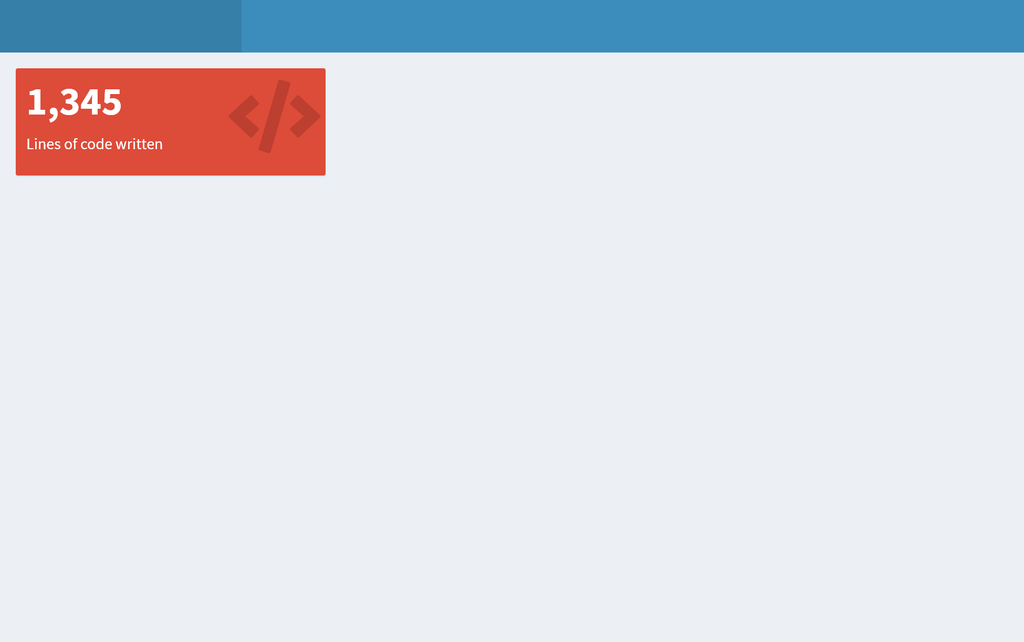

Figure 2: The most simple value box

So here it is, a simple value box to emphasize information which can have an icon/color to give some meaning to the number.

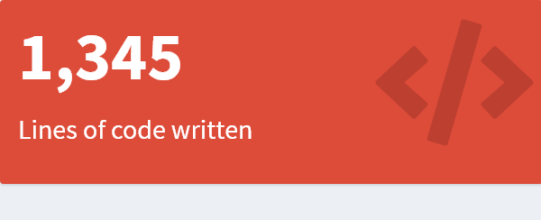

Figure 3: Apply some zoom

## Modifying the `valueBox`

Before to modify a value box we need to know what a `valueBox` is, or how is it built, so take a look what is inside this funcion.

```
valueBox

function(value, subtitle, icon = NULL, color = "aqua", width = 4, href = NULL){

  validateColor(color)

  if (!is.null(icon))
    tagAssert(icon, type = "i")

  boxContent <- div(
    class = paste0("small-box bg-", color),
    div(
      class = "inner",
      h3(value),
      p(subtitle)
      ),
    if (!is.null(icon)) div(class = "icon-large", icon)
    )

  if (!is.null(href))
    boxContent <- a(href = href, boxContent)

  div(
    class = if (!is.null(width)) paste0("col-sm-", width),
    boxContent
    )
}
```

As we see, the `value` and `subtitle` arguments are the main ones. The other are just for styling and format. These elements are in `div(class = "inner", ...)` so here we’ll put the new content.

Let’s try to put a title in the top of the div and then use the subtitle as an detailed text.

```
valueBox2 <- function(value, title, subtitle, icon = NULL, color = "aqua", width = 4, href = NULL){

  shinydashboard:::validateColor(color)

  if (!is.null(icon))
    shinydashboard:::tagAssert(icon, type = "i")

  boxContent <- div(
    class = paste0("small-box bg-", color),
    div(
      class = "inner",
      tags$small(title),
      h3(value),
      p(subtitle)
      ),
    if (!is.null(icon)) div(class = "icon-large", icon)
    )

  if (!is.null(href))
    boxContent <- a(href = href, boxContent)

  div(
    class = if (!is.null(width)) paste0("col-sm-", width),
    boxContent
    )
}
```

So the implementation is the same as the original `valueBox` function:

```
vb <- valueBox2(
  value = "1,345",
  title = toupper("Lines of code"),
  subtitle = tagList(HTML("&uarr;"), "25% Since last day"),
  icon = icon("code"),
  width = 4,
  color = "red",
  href = NULL
  )
```

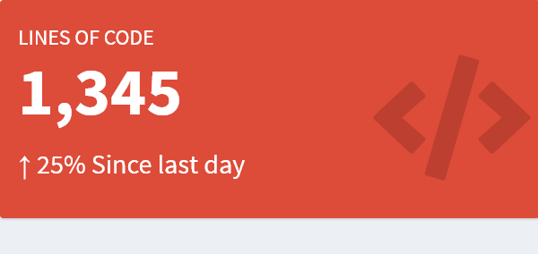

Figure 4: A modificated value box

The idea of put a title is to help the reader, but we use a small text to be *subtle*, usually I like to use a *Small Caps* font but in this case I used uppercase for simplicity.

## Adding sparklines

The idea to add a sparkline to the value box is give more information. For example, if your have a historical data, it would be good put a sparkline to show the previous behaviour about the data, so you can compare the *BIG* number with the past.

Let’s simulate data to create a sparkline:

```
set.seed(123)

N <- 20

x <- cumsum(rnorm(N)) + 0.5 * cumsum(runif(N))
x <- round(200*x)

df <- data.frame(
  x = sort(as.Date(Sys.time() - lubridate::days(1:N))),
  y = abs(x)
)

df
```

```
            x    y
1  2020-12-21   98
2  2020-12-22  102
3  2020-12-23  251
4  2020-12-24  302
5  2020-12-25  343
6  2020-12-26  700
7  2020-12-27  815
8  2020-12-28  609
9  2020-12-29  498
10 2020-12-30  495
11 2020-12-31  744
12 2021-01-01  860
13 2021-01-02 1020
14 2021-01-03 1055
15 2021-01-04 1000
16 2021-01-05 1378
17 2021-01-06 1490
18 2021-01-07 1172
19 2021-01-08 1402
20 2021-01-09 1345
```

Let’s create a sparkline with {highcharter} package:

```
library(highcharter)

hc <- hchart(df, "line", hcaes(x, y), name = "lines of code")  %>%
  hc_size(height = 100)

hc
```

[interactive chart not shown]

We have our first sparkline. It’s important note the `hc` object will use the available horizontal (`width`) space, but we need to control the `heigth`.

Now we can create a new `valueBox` function;

```
valueBox3 <- function(value, title, sparkobj = NULL, subtitle, icon = NULL,
                      color = "aqua", width = 4, href = NULL){

  shinydashboard:::validateColor(color)

  if (!is.null(icon))
    shinydashboard:::tagAssert(icon, type = "i")

  boxContent <- div(
    class = paste0("small-box bg-", color),
    div(
      class = "inner",
      tags$small(title),
      h3(value),
      if (!is.null(sparkobj)) sparkobj,
      p(subtitle)
      ),
    if (!is.null(icon)) div(class = "icon-large", icon, style = "z-index; 0")
    )

  if (!is.null(href))
    boxContent <- a(href = href, boxContent)

  div(
    class = if (!is.null(width)) paste0("col-sm-", width),
    boxContent
    )
}
```

So now:

```
vb <- valueBox3(
  value = "1,345",
  title = toupper("Lines of code"),
  sparkobj = hc,
  subtitle = tagList(HTML("&uarr;"), "25% Since last day"),
  icon = icon("code"),
  width = 4,
  color = "red",
  href = NULL)
```

And the result is:

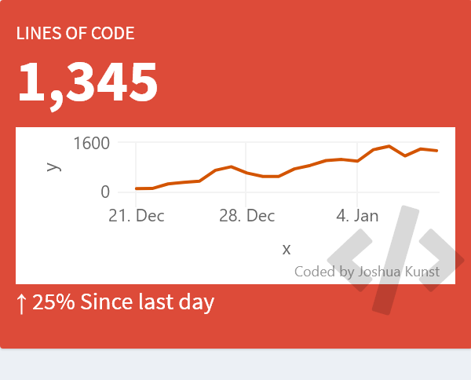

Figure 5: A value box with a sparkline using a bad theme

LOL! We need modify the look of the chart. For this we’ll create a custom theme. The general idea is gain space via removing axis and borders. Then have cleaner look removing grid lines… You know, show *just* the line.

```
hc_theme_sparkline_vb <- function(...) {

  theme <- list(
    chart = list(
      backgroundColor = NULL,
      margins = c(0, 0, 0, 0),
      spacingTop = 0,
      spacingRight = 0,
      spacingBottom = 0,
      spacingLeft = 0,
      plotBorderWidth = 0,
      borderWidth = 0,
      style = list(overflow = "visible")
    ),
    xAxis = list(
      visible = FALSE,
      endOnTick = FALSE,
      startOnTick = FALSE
    ),
    yAxis = list(
      visible = FALSE,
      endOnTick = FALSE,
      startOnTick = FALSE
    ),
    tooltip = list(
      outside = FALSE,
      shadow = FALSE,
      borderColor = "transparent",
      botderWidth = 0,
      backgroundColor = "transparent",
      style = list(textOutline = "5px white")
    ),
    plotOptions = list(
      series = list(
        marker = list(enabled = FALSE),
        lineWidth = 2,
        shadow = FALSE,
        fillOpacity = 0.25,
        color = "#FFFFFFBF",
        fillColor = list(
          linearGradient = list(x1 = 0, y1 = 1, x2 = 0, y2 = 0),
          stops = list(
            list(0.00, "#FFFFFF00"),
            list(0.50, "#FFFFFF7F"),
            list(1.00, "#FFFFFFFF")
          )
        )
      )
    ),
    credits = list(
      enabled = FALSE,
      text = ""
      )
    )

  theme <- structure(theme, class = "hc_theme")

  if (length(list(...)) > 0) {
    theme <- hc_theme_merge(
      theme,
      hc_theme(...)
    )
  }

  theme
}
```

Testing the theme.

```
hc <- hc %>%
  hc_add_theme(hc_theme_sparkline_vb()) %>%
  hc_credits(enabled = FALSE)

hc %>%
  # emulate the background color of the valueBox
  hc_chart(backgroundColor = "#DD4B39")
```

[interactive chart not shown]

And trying again:

```
vb <- valueBox3(
  value = "1,345",
  title = toupper("Lines of code"),
  sparkobj = hc,
  subtitle = tagList(HTML("&uarr;"), "25% Since last day"),
  icon = icon("code"),
  width = 4,
  color = "red",
  href = NULL)
```

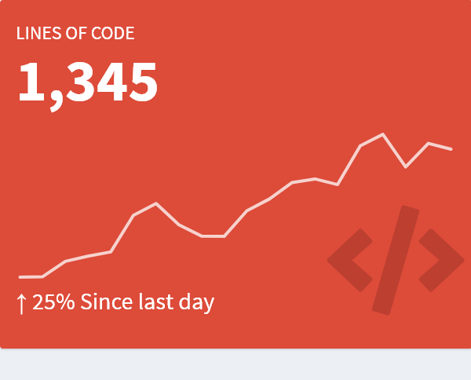

Figure 6: A value box with a proper sparkline

## Including an information helper

Sometimes I like to add helper information icon to explain how to read the metric/number if is needed.

This can be done using the icon `"info-cirle"` and using the class `"pull-right"` to put in the corner.

```
valueBox4 <- function(value, title, sparkobj = NULL, subtitle, info = NULL,
                      icon = NULL, color = "aqua", width = 4, href = NULL){

  shinydashboard:::validateColor(color)

  if (!is.null(icon))
    shinydashboard:::tagAssert(icon, type = "i")

  info_icon <- tags$small(
    tags$i(
      class = "fa fa-info-circle fa-lg",
      title = info,
      `data-toggle` = "tooltip",
      style = "color: rgba(255, 255, 255, 0.75);"
      ),
    class = "pull-right"
    )

  boxContent <- div(
    class = paste0("small-box bg-", color),
    div(
      class = "inner",
      tags$small(title),
      if (!is.null(sparkobj)) info_icon,
      h3(value),
      if (!is.null(sparkobj)) sparkobj,
      p(subtitle)
      ),
    if (!is.null(icon)) div(class = "icon-large", icon, style = "z-index; 0")
    )

  if (!is.null(href))
    boxContent <- a(href = href, boxContent)

  div(
    class = if (!is.null(width)) paste0("col-sm-", width),
    boxContent
    )
}
```

So now:

```
vb <- valueBox4(
  value = "1,345",
  title = toupper("Lines of code"),
  sparkobj = hc,
  subtitle = tagList(HTML("&uarr;"), "25% Since last day"),
  info = "This is the lines of code I've written in the past 20 days! That's a lot, right?",
  icon = icon("code"),
  width = 4,
  color = "red",
  href = NULL
  )
```

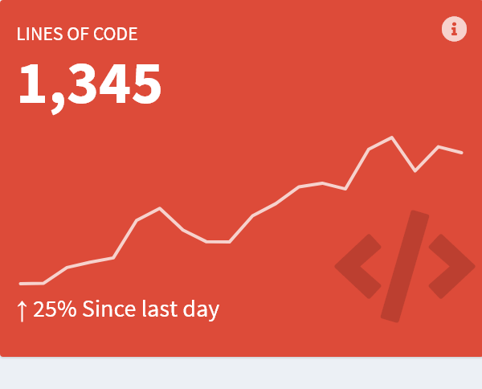

Figure 7: A value box with helper text on hover

*Voilà* we have a value box with a information helper.

## Demo

Demo section! We can use other types of charts, texts and colors:

Before the demo, let’s give a proper name to our function:

```
valueBoxSpark <- function(value, title, sparkobj = NULL, subtitle, info = NULL,
                          icon = NULL, color = "aqua", width = 4, href = NULL){

  shinydashboard:::validateColor(color)

  if (!is.null(icon))
    shinydashboard:::tagAssert(icon, type = "i")

  info_icon <- tags$small(
    tags$i(
      class = "fa fa-info-circle fa-lg",
      title = info,
      `data-toggle` = "tooltip",
      style = "color: rgba(255, 255, 255, 0.75);"
      ),
    # bs3 pull-right
    # bs4 float-right
    class = "pull-right float-right"
    )

  boxContent <- div(
    class = paste0("small-box bg-", color),
    div(
      class = "inner",
      tags$small(title),
      if (!is.null(sparkobj)) info_icon,
      h3(value),
      if (!is.null(sparkobj)) sparkobj,
      p(subtitle)
      ),
    # bs3 icon-large
    # bs4 icon
    if (!is.null(icon)) div(class = "icon-large icon", icon, style = "z-index; 0")
    )

  if (!is.null(href))
    boxContent <- a(href = href, boxContent)

  div(
    class = if (!is.null(width)) paste0("col-sm-", width),
    boxContent
    )
}
```

Some charts:

```
hc <- hchart(df, "area", hcaes(x, y), name = "lines of code")  %>%
  hc_size(height = 100) %>%
  hc_credits(enabled = FALSE) %>%
  hc_add_theme(hc_theme_sparkline_vb())

hc2 <- hchart(df, "line", hcaes(x, y), name = "Distance")  %>%
  hc_size(height = 100) %>%
  hc_credits(enabled = FALSE) %>%
  hc_add_theme(hc_theme_sparkline_vb())

hc3 <- hchart(df, "column", hcaes(x, y), name = "Daily amount")  %>%
  hc_size(height = 100) %>%
  hc_credits(enabled = FALSE) %>%
  hc_add_theme(hc_theme_sparkline_vb())
```

Some value boxes:

```
vb <- valueBoxSpark(
  value = "1,345",
  title = toupper("Lines of code written"),
  sparkobj = hc,
  subtitle = tagList(HTML("&uarr;"), "25% Since last day"),
  info = "This is the lines of code I've written in the past 20 days! That's a lot, right?",
  icon = icon("code"),
  width = 4,
  color = "teal",
  href = NULL
  )

vb2 <- valueBoxSpark(
  value = "1,345 KM",
  title = toupper("Distance Traveled"),
  sparkobj = hc2,
  subtitle = tagList(HTML("&uarr;"), "25% Since last month"),
  info = "This is the lines of code I've written in the past 20 days! That's a lot, right?",
  icon = icon("plane"),
  width = 4,
  color = "red",
  href = NULL
  )

vb3 <- valueBoxSpark(
  value = "1,3 Hrs.",
  title = toupper("Thinking time"),
  sparkobj = hc3,
  subtitle = tagList(HTML("&uarr;"), "5% Since last year"),
  info = "This is the lines of code I've written in the past 20 days! That's a lot, right?",
  icon = icon("hourglass-half"),
  width = 4,
  color = "yellow",
  href = NULL
  )
```

Finally the app:

```
library(shiny)
library(shinydashboard)

ui <- dashboardPage(
  dashboardHeader(),
  dashboardSidebar(disable = TRUE),
  dashboardBody(
    fluidRow(
      valueBoxOutput("vbox"),
      valueBoxOutput("vbox2"),
      valueBoxOutput("vbox3")
    )
  )
)

server <- function(input, output) {
  output$vbox <- renderValueBox(vb)
  output$vbox2 <- renderValueBox(vb2)
  output$vbox3 <- renderValueBox(vb3)
}

# shiny::shinyApp(ui, server, options = list(launch.browser = .rs.invokeShinyPaneViewer))
```

This app look like this :)! What do you think?

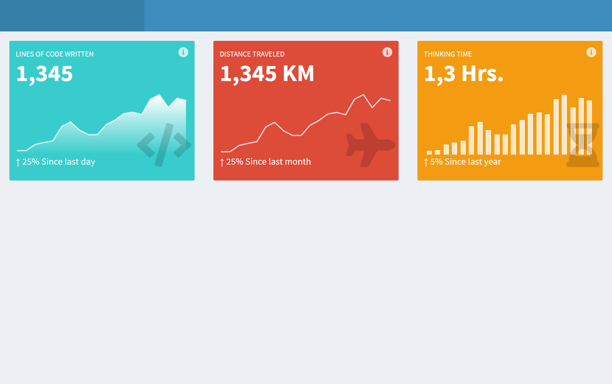

Figure 8: Awesome new value boxes

## Extending the idea

```
library(bs4Dash)

ui <- bs4DashPage(
  navbar = bs4DashNavbar(),
  sidebar = bs4DashSidebar(disable = TRUE),
  body = bs4DashBody(
    # this is for use tooltips in the bs4dash package
    tags$script(HTML("setInterval(function(){ $('[title]').tooltip(); }, 1000)")),
    tags$h2("Testing with {bs4dash} package"),
    tags$hr(),
    fluidRow(
      valueBoxOutput("vbox"),
      valueBoxOutput("vbox2"),
      valueBoxOutput("vbox3")
      )
    )
  )

# setTimeout(function(){ $('[title]').tooltip(); }, 3000)
# setInterval(function(){ $('[title]').tooltip(); }, 3000)
# JS("$(function () { $('[title]').tooltip() })")
```

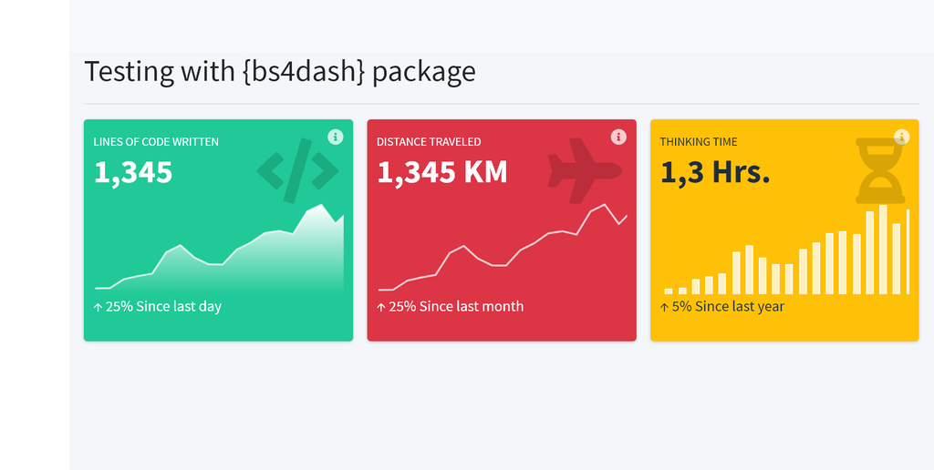

Figure 9: Work with the {bs4dash} package too

This walkthrough/tutorial will help to implement sparklines in other packages as well as other elements such as `infoBox`, or maybe with other htmlwidgets like {echarts4r} or {plotly}. So if you make an implementation please tell us and share with other people.